# Analyzing Quantitative Data

GE2021 Research Technology, Fall 2026

Chad (Chungil Chae)

cchae@kean.edu

Tue, 15 September 2026

# Learning Objectives

- 10-1 Summarize why statistics are used in research methods
- 10-2 Conduct univariate analysis
- 10-3 Explain the measures of central tendency
- 10-4 Define measures of variability and dispersion
- 10-5 Describe the various ways to graphically represent data
- 10-6 Conduct bivariate analysis

## SHORT VIDEO INTRODUCTION

[video not shown]

# Analyzing Quantitative Data

- Statistics: a branch of mathematics that uses mathematical logic to interpret phenomena and draw conclusions from the accumulated data.
- It establishes relationships between and among variables and can even attempt to predict future behaviors or relationships.

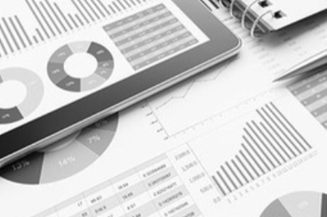

# Univariate Analysis

- Univariate analysis: the analysis of only one variable.
- Descriptive analysis: allows researchers to sketch the details of variables and gain familiarity with the sample; gives an idea of the descriptive characteristics of variables.
  - Descriptive statistics describe the first impressions of a variable.
- Inferential analysis/statistics: provide a deeper understanding of the variables because it draws conclusions about the population from the sample at hand.
  - This type of analysis goes beyond the description of the data available and attempts to draw relationships or associations between variables.
  - Once a relationship is detected between variables, inferential statistics attempts to predict the possibility of applying the same relationship to the entire population of the study.
- Inferential statistics operate by trying to calculate the random error that occurs during collection and analysis.
- Random error: associated with the type of common mistakes or errors that happen by chance when data are collected or entered into a spreadsheet or during analysis.
- Sampling error: a random error that occurs during the process of data collection.
  - Inferential statistics only investigates the sampling error that can happen randomly; it is unable to identify a systematic sampling error.

> Univariate analysis is the first step researchers take to familiarize themselves with the population sample.
- Frequency Distributions
  - Constructing a frequency distribution with data is a simple procedure that can illustrate key characteristics of participants in the sample.
  - The first indicator is absolute frequency, which reflects the number of times an event or instance has been repeated.
  - Assigning percentages to each category adds another layer of valuable information.
    - Percentages are capable of zooming out from the raw numbers because it compares the raw numbers to the entire sampling population.
  - Cumulative percent: another descriptive measure of frequency; shows the collective percentage of categories together.
    - It is sensitive to the order of organization.

# Measure of Central Tendency

> Measures of central tendency: summarize an entire variable or category in a single value that is numerically representative of it.
- Mean: the mathematical average of a set of numbers; all numbers in a variable category are added together and then divided by n, which is the total number of entries in that data set.
  - The mean is useful for comparing two or more groups.
  - The mean takes into account every single point in the variable, and it is very sensitive to outliers.
  - Outlier: a data point that is much higher or lower than the majority of other points.
- Median: represents the center point in a set of numbers that have been arranged in ascending or descending order.
  - The median is useful in statistics because it gives an understanding about the distribution of a variable.
- Mode: the most frequently used number in a data set; which number is most commonly encountered in a specific set of numbers.
  - The mode can provide additional information that can potentially clarify any misleading information from the mean or median.
  - One variable can have more than one mode.
    - Unimodal: only one mode
    - Bimodal: two modes
    - Multimodal: three or more modes

# Measures of Variability and Dispersion

- Measures of central tendency tell about the middle scores in a distribution, but they tell very little about how they are spread out.
- Measures of variability and dispersion are the ones that give information about how far apart or close by the values are in a distribution.
- Variability expresses the degree to which data in a data set spreads out, or deviates, from the center.
- Homogenous: sets that have little variability
- Heterogenous: sets with a lot of variability
  - Pose a higher level of complexity in approaching analysis.
- Range: the difference between the largest and smallest numbers in the set.
  - Interquartile range (IQR) is another measure of the middle 50% of the scores in a variable
- Variance: represents each datapoint’s average deviation from the mean; the average sum of the squared distance of every single point in the data set from the mean.
- Standard deviation: the square root of the variance; also represents each data point’s average deviation from the mean.

## Normal Distribution

- The normal distribution is a theoretical perfect distribution where the mean, mode, and median are equal to one another.
  - It is symmetrical; the mean divides the distribution into equal halves.
  - It is used to compare against the actual distribution.
- Standard scores: also called z scores; indicate the number of standard deviations in a distribution and what proportion of the scores fall within this range.

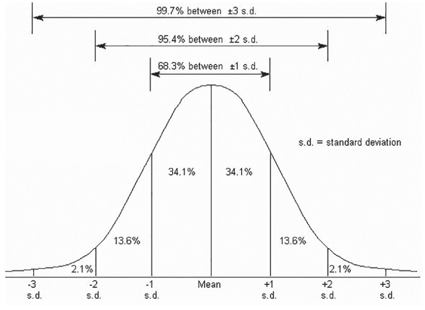

## Skewness and Kurtosis

- Skewness: when a distribution lacks the symmetry created when the mean, median, and mode are in the center; its shape is asymmetric when viewed in a histogram.
  - The term used to note that a distribution is clustered on the right or the left.
  - A distribution with a long tail on the left side and a majority of data on the right is called left-skew, left-tailed, or negatively skewed distribution.
  - A distribution with a long tail on the right but a majority of points of the left is called a right-skew, right-tailed, or positively skewed distribution.
  - In right/positively skewed distributions, the mode will be on the left of the distribution where the highest peak is, the median will have a greater value than the mode, and the mean will have a higher value than the median and mode.
  - The opposite occurs in left/negatively skewed distributions; the mean will have the smallest value, followed by the median, and then the mode, which will be at the highest peak.
- Kurtosis: refers to the flatness of the distribution and the flatness of its tails.
  - The two characteristics work together; a high peak in the distribution also has long flat tails.
    - Leptokurtic: distribution with a high peak and long flat tails
    - Platykurtic: distribution with a flat peak and short tails.
  - Kurtosis is an indication that some problematic outliers are present in the distribution.
  - If kurtosis is noted during analysis, the researcher will often take another look at the distribution to possibly remove outliers and bring the distribution to a shape closer to normal distribution.

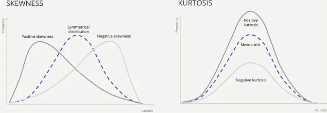

## Continuous and Discrete Variables

- Discrete variables: categorical variables that can only take whole numbers and do not have any continuity in terms of measurement.
  - Example: number of employees in an institution
- Continuous variable: a type of numerical variable that can take all possible units
  - Examples: income, height, weight

# Graphical Representation of Data

> A graphic representation of information can have a powerful impact on a broader audience, visually depicting relationships and patterns among variables.
- Bar graphs: use vertical bars that represent each variable in a study.
  - The viewer can easily distinguish not only which category occurs most frequently, but how it compares to the other categories.

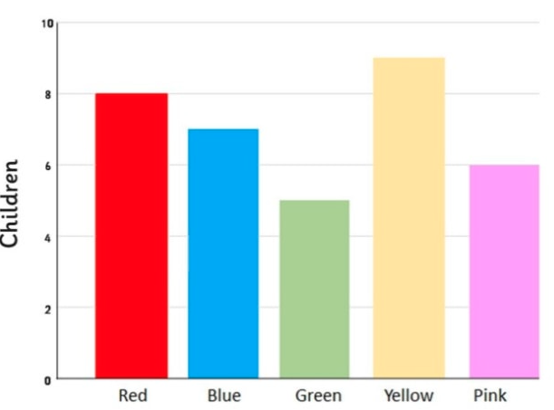

- Histograms: often used for quantitative variables where the categories are related to one another.
  - Presents the frequency of a variable in the form of distinct but connected bars.

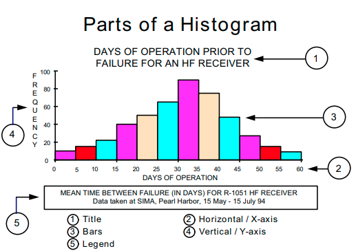

- Line graph: a line connecting points in a distribution.
  - Useful in depicting two or more categories simultaneously, or if there are multiple distributions in the same category.
  - A line graph is an effective way to demonstrate relationships between variables.

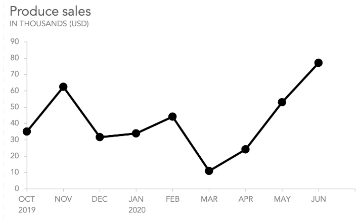

- Pie charts: a visual representation of the distribution of one variable.
  - Work best with categorical variables that have a small number of categories.
  - The main advantage of a pie chart is its visual impact on the audience.

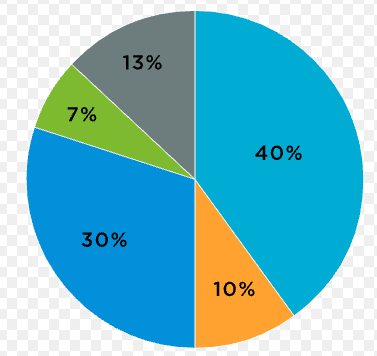